# Lasso

Callie Stephenson

2024-07-21

# Correlation of response variables:

### Symbionts and growth:

In coral biology, we generally assume more symbionts -> more photosynthetic carbon. Therefore, we’d expect that more symbionts -> more growth. In some cases, symbiont populations can become parasitic and hoard resources for themselves. This has been shown at much higher levels of symbionts than seen in this experiment (1-3 x 10^6). So, we’d traditionally expect that more symbionts would lead to higher coral growth. Except….

Percent change in buoyant weight is related to symbiont population only in Porites rus, not in Pocillopora acuta:

```
## # A tibble: 2 × 4
##   Species           P_Value Marginal_R2 Conditional_R2
##   <chr>               <dbl>       <dbl>          <dbl>
## 1 Pocillopora acuta  0.914     0.000183          0.197
## 2 Porites rus        0.0179    0.214             0.358
```

This can be shown graphically. In the first version of this plot, you are only looking at caged P. rus. In the second version, you are seeing all corals in the experiment

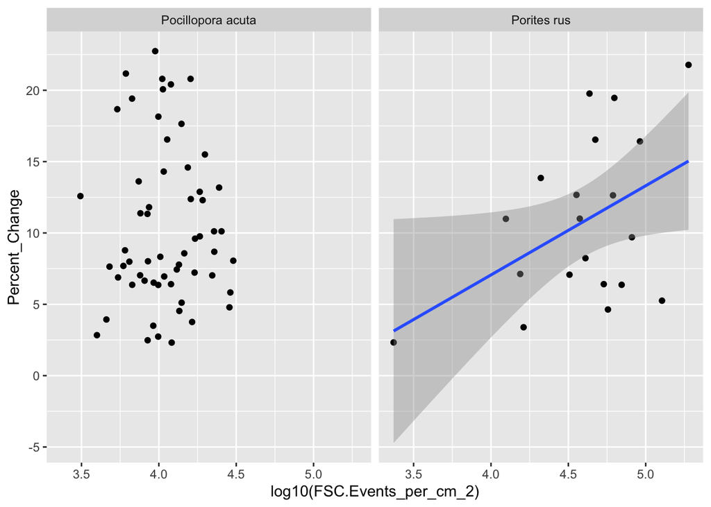

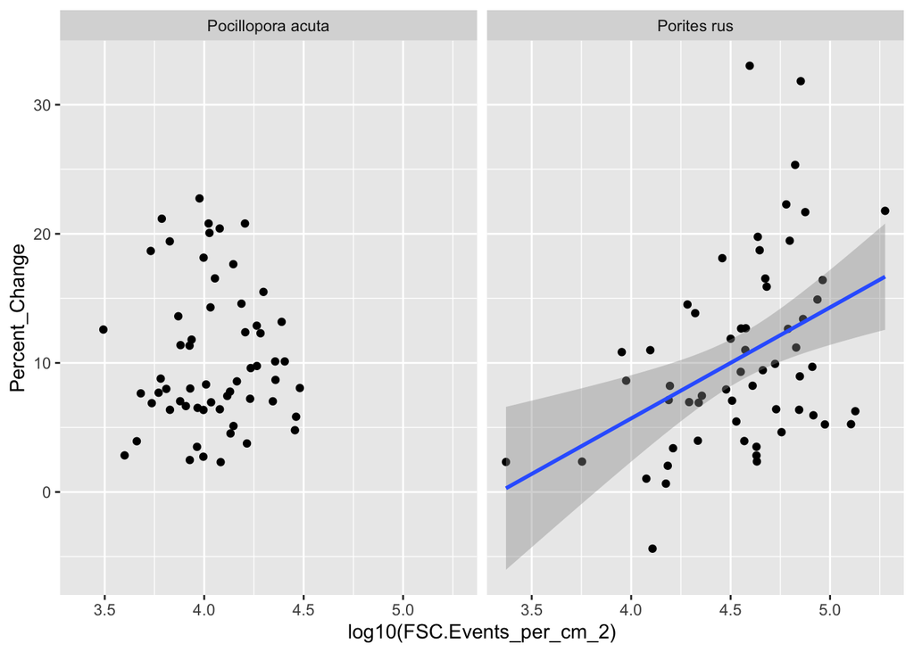

## Isotopes and growth

Now, instead of growing faster because the corals were photosynthesizing more, perhaps the corals were instead feeding more heterotrophically. We test this with Δ13C, which represents how much more δ13C is in the host tissue versus the symbiont.

```
## # A tibble: 2 × 4
##   Species           P_Value Marginal_R2 Conditional_R2
##   <chr>               <dbl>       <dbl>          <dbl>
## 1 Pocillopora acuta   0.764     0.00472        0.00472
## 2 Porites rus         0.158     0.0998         0.0998
```

NOPE, and we can see this graphically:

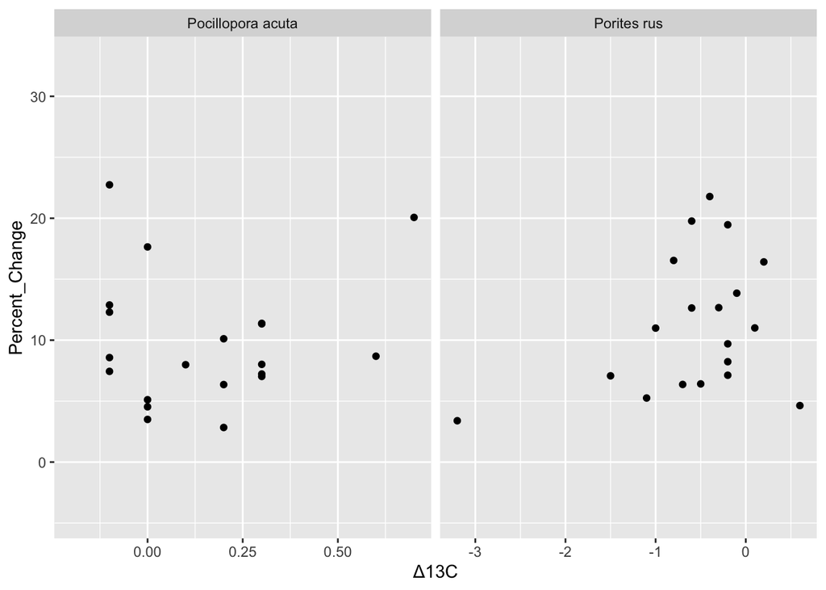

## Both

Since neither relationship is clean, it might be because they are explaining seperate parts of the variation in the growth data. For example, if the variables are not collinear (and thus whatever is driving corals eating is different than whatever is driving increases in symbiont populations), then it is possible that both are contributing to the variation in this dataset.

```
## # A tibble: 2 × 5
##   Species           P_Value_Δ13C P_Value_symb Marginal_R2 Conditional_R2
##   <chr>                    <dbl>        <dbl>       <dbl>          <dbl>
## 1 Pocillopora acuta        0.759        0.655      0.0148         0.0148
## 2 Porites rus              0.386        0.297      0.130          0.182
```

Still no! It looks like neither is a good explainer of variation in the growth data.

## What does this mean

This can also be shown through basic correlation plots of the repsonse variables. I like this version from Performance Analytics:

#### Here, for P. rus:

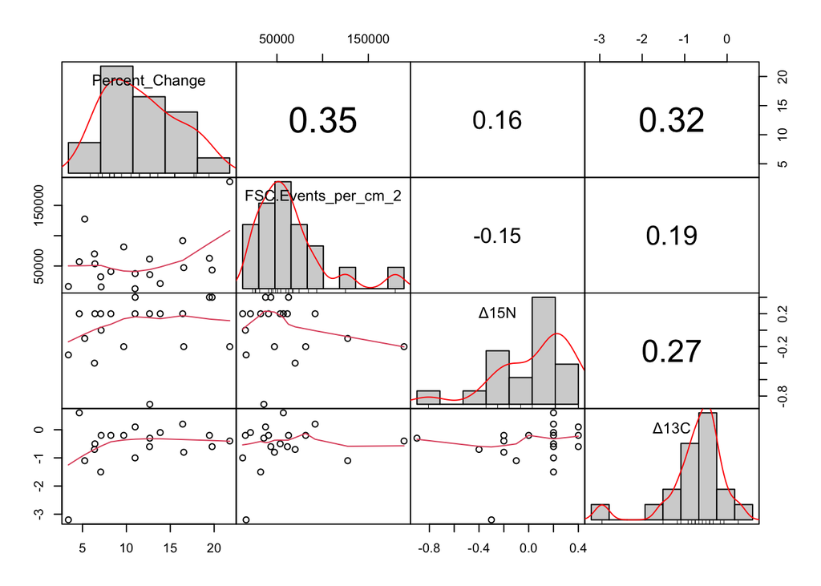

#### or for P.acuta:

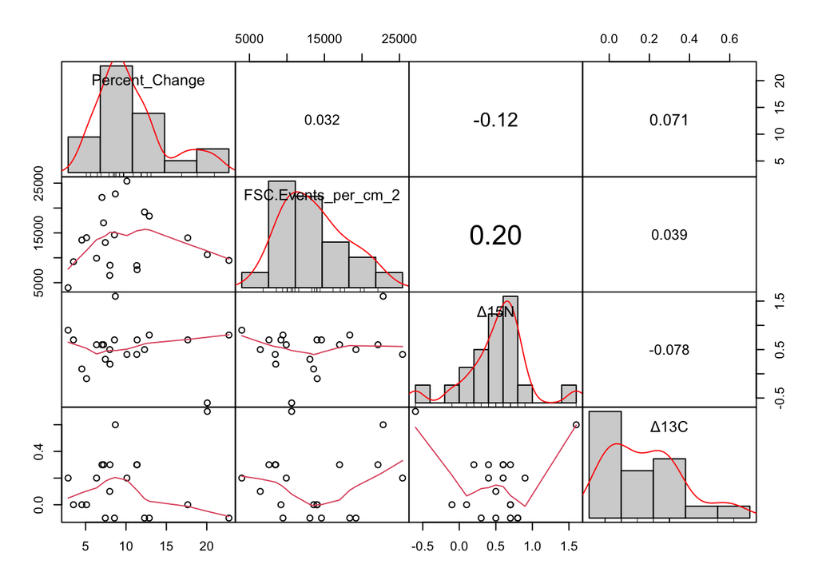

Next, I will explore what aspects of the gradient are effecting these response variables to gain a deeper understanding of coral holobiont response to SGD.

But first, let’s explore the correlation of the explanatory variables:

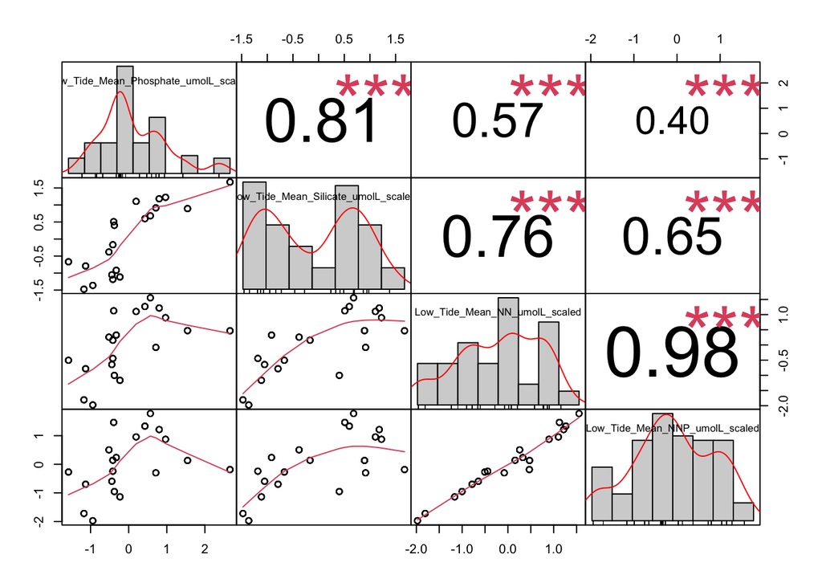

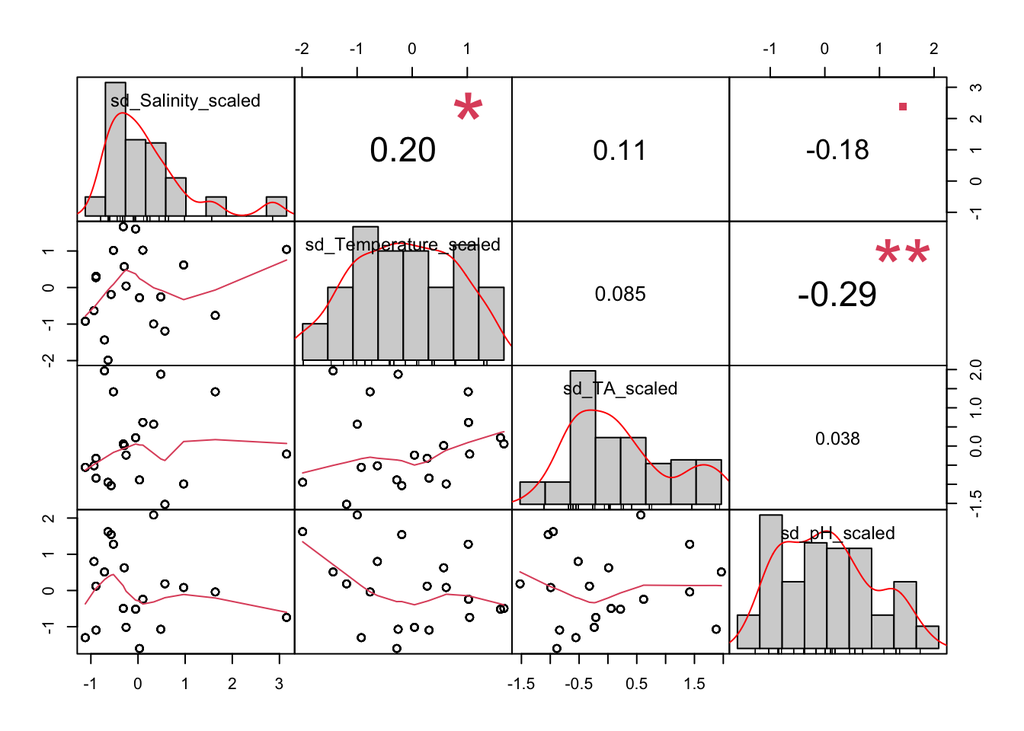

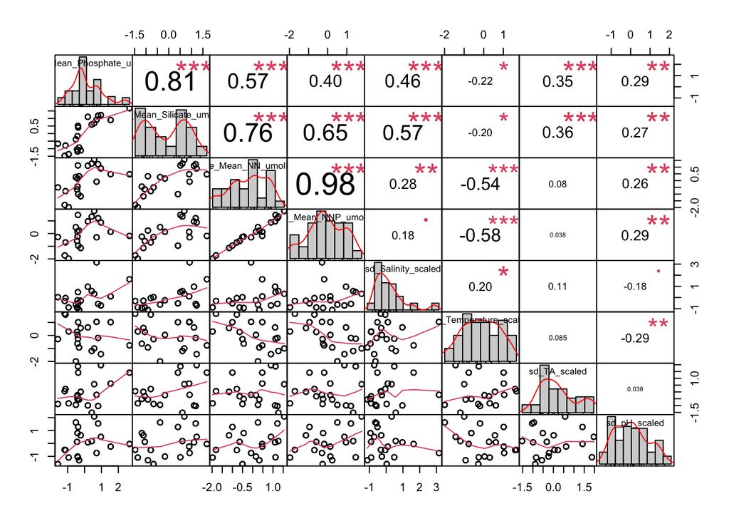

# Lets start with growth of P. acuta

```
## 18 x 1 sparse Matrix of class "dgCMatrix"
##                                              s1
## (Intercept)                          10.0866609
## Low_Tide_Mean_Phosphate_umolL_scaled  .
## Low_Tide_Mean_Silicate_umolL_scaled   .
## Low_Tide_Mean_NN_umolL_scaled         .
## Low_Tide_Mean_NNP_umolL_scaled        .
## sd_Salinity_scaled                    .
## sd_Temperature_scaled                 0.8414302
## sd_TA_scaled                          1.5906323
## sd_pH_scaled                          2.1333171
## GenotypePA11                          .
## GenotypePA13                          .
## GenotypePA18                          .
## GenotypePA19                          .
## GenotypePA21                          2.5590045
## GenotypePA22                         -1.8399015
## Cage_UncagedA                         .
## Cage_UncagedB                        -0.0635102
## Cage_UncagedC                         0.6116534
```

```
## Linear mixed model fit by REML. t-tests use Satterthwaite's method [
## lmerModLmerTest]
## Formula:
## Percent_Change ~ sd_Temperature_scaled + sd_TA_scaled + sd_pH_scaled +
##     (1 | Genotype) + (1 | Cage_Uncaged)
##    Data: model_data %>% filter(Species == "Pocillopora acuta")
##
## REML criterion at convergence: 327.5
##
## Scaled residuals:
##      Min       1Q   Median       3Q      Max
## -2.05511 -0.60060 -0.07507  0.78966  2.33111
##
## Random effects:
##  Groups       Name        Variance Std.Dev.
##  Genotype     (Intercept)  6.898   2.6264
##  Cage_Uncaged (Intercept)  0.628   0.7925
##  Residual                 14.327   3.7850
## Number of obs: 59, groups:  Genotype, 6; Cage_Uncaged, 3
##
## Fixed effects:
##                       Estimate Std. Error      df t value Pr(>|t|)
## (Intercept)            10.4042     1.2677  5.0150   8.207 0.000431 ***
## sd_Temperature_scaled   1.8031     0.5329 50.1737   3.384 0.001394 **
## sd_TA_scaled            2.3370     0.7144 43.9999   3.271 0.002085 **
## sd_pH_scaled            3.2100     0.6079 53.0361   5.280 2.45e-06 ***
## ---
## Signif. codes:  0 '***' 0.001 '**' 0.01 '*' 0.05 '.' 0.1 ' ' 1
##
## Correlation of Fixed Effects:
##             (Intr) sd_Tm_ sd_TA_
## sd_Tmprtr_s  0.002
## sd_TA_scald  0.038  0.047
## sd_pH_scald  0.014  0.275 -0.013
```

```
## Analysis of Deviance Table (Type II Wald chisquare tests)
##
## Response: Percent_Change
##                        Chisq Df Pr(>Chisq)
## sd_Temperature_scaled 11.450  1  0.0007149 ***
## sd_TA_scaled          10.702  1  0.0010704 **
## sd_pH_scaled          27.881  1   1.29e-07 ***
## ---
## Signif. codes:  0 '***' 0.001 '**' 0.01 '*' 0.05 '.' 0.1 ' ' 1
```

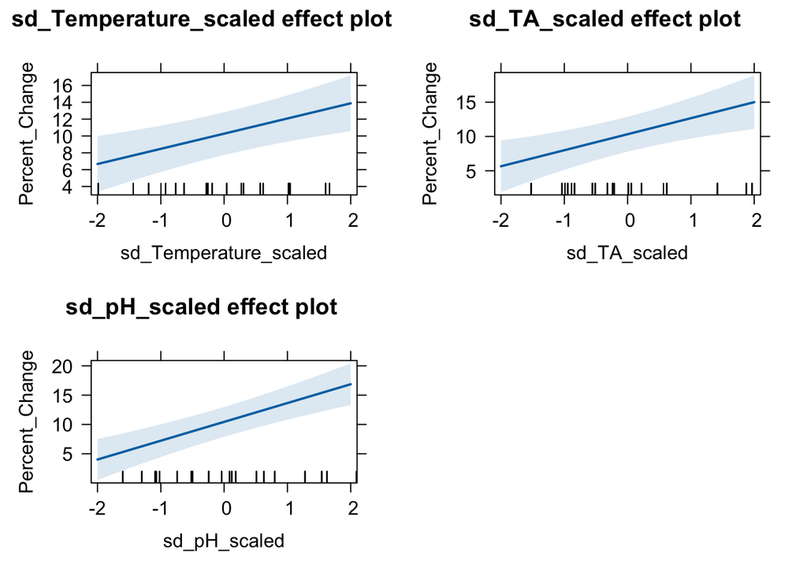

This shows that what was most predictive of growth in the Pocillopora acuta was the variability in the biophysical environment, as quantified by temperature, total alkalinity, and pH.

```
## 26 x 1 sparse Matrix of class "dgCMatrix"
##                                                      s1
## (Intercept)                                 10.22732257
## GenotypePA11                                 .
## GenotypePA13                                 .
## GenotypePA18                                 .
## GenotypePA19                                 .
## GenotypePA21                                 2.50620667
## GenotypePA22                                -1.70428748
## Cage_UncagedA                                .
## Cage_UncagedB                               -0.06351458
## Cage_UncagedC                                0.60358030
## Low_Tide_Mean_Phosphate_umolL_scaled_poly_1  .
## Low_Tide_Mean_Phosphate_umolL_scaled_poly_2  .
## Low_Tide_Mean_Silicate_umolL_scaled_poly_1   .
## Low_Tide_Mean_Silicate_umolL_scaled_poly_2  -0.15198939
## Low_Tide_Mean_NN_umolL_scaled_poly_1         .
## Low_Tide_Mean_NN_umolL_scaled_poly_2         .
## Low_Tide_Mean_NNP_umolL_scaled_poly_1        .
## Low_Tide_Mean_NNP_umolL_scaled_poly_2        .
## sd_Salinity_scaled_poly_1                    .
## sd_Salinity_scaled_poly_2                    .
## sd_Temperature_scaled_poly_1                 0.84028430
## sd_Temperature_scaled_poly_2                 .
## sd_TA_scaled_poly_1                          1.58987541
## sd_TA_scaled_poly_2                          .
## sd_pH_scaled_poly_1                          2.13268073
## sd_pH_scaled_poly_2                          .
```

```
## Start:  AIC=174.05
## Percent_Change ~ Low_Tide_Mean_Phosphate_umolL_scaled + Low_Tide_Mean_Silicate_umolL_scaled +
##     Low_Tide_Mean_NN_umolL_scaled + Low_Tide_Mean_NNP_umolL_scaled +
##     sd_Salinity_scaled + sd_Temperature_scaled + sd_TA_scaled +
##     sd_pH_scaled + GenotypePA11 + GenotypePA13 + GenotypePA18 +
##     GenotypePA19 + GenotypePA21 + GenotypePA22 + Cage_UncagedA +
##     Cage_UncagedB + Cage_UncagedC
##
##
## Step:  AIC=174.05
## Percent_Change ~ Low_Tide_Mean_Phosphate_umolL_scaled + Low_Tide_Mean_Silicate_umolL_scaled +
##     Low_Tide_Mean_NN_umolL_scaled + Low_Tide_Mean_NNP_umolL_scaled +
##     sd_Salinity_scaled + sd_Temperature_scaled + sd_TA_scaled +
##     sd_pH_scaled + GenotypePA11 + GenotypePA13 + GenotypePA18 +
##     GenotypePA19 + GenotypePA21 + GenotypePA22 + Cage_UncagedA +
##     Cage_UncagedB
##
##
## Step:  AIC=174.05
## Percent_Change ~ Low_Tide_Mean_Phosphate_umolL_scaled + Low_Tide_Mean_Silicate_umolL_scaled +
##     Low_Tide_Mean_NN_umolL_scaled + Low_Tide_Mean_NNP_umolL_scaled +
##     sd_Salinity_scaled + sd_Temperature_scaled + sd_TA_scaled +
##     sd_pH_scaled + GenotypePA11 + GenotypePA13 + GenotypePA18 +
##     GenotypePA19 + GenotypePA21 + Cage_UncagedA + Cage_UncagedB
##
##                                        Df Sum of Sq    RSS    AIC
## - Low_Tide_Mean_Silicate_umolL_scaled   1     0.157 655.46 172.06
## - GenotypePA13                          1     2.441 657.75 172.27
## - sd_Salinity_scaled                    1     5.252 660.56 172.52
## - GenotypePA11                          1    11.423 666.73 173.07
## - sd_TA_scaled                          1    11.853 667.16 173.10
## - Cage_UncagedA                         1    15.149 670.46 173.40
## - GenotypePA18                          1    20.537 675.84 173.87
## <none>                                              655.31 174.05
## - Low_Tide_Mean_Phosphate_umolL_scaled  1    25.108 680.42 174.26
## - Low_Tide_Mean_NN_umolL_scaled         1    26.210 681.52 174.36
## - Low_Tide_Mean_NNP_umolL_scaled        1    28.143 683.45 174.53
## - GenotypePA19                          1    37.060 692.37 175.29
## - Cage_UncagedB                         1    47.553 702.86 176.18
## - sd_pH_scaled                          1    81.688 737.00 178.98
```

[output cut: 139 more lines]

```
## + Cage_UncagedC                         1    16.505 694.70 167.49
## - Cage_UncagedB                         1    34.184 745.39 167.65
## + GenotypePA22                          1    10.571 700.63 167.99
## + sd_TA_scaled                          1     7.897 703.31 168.22
## + GenotypePA11                          1     4.364 706.84 168.51
## + Low_Tide_Mean_Silicate_umolL_scaled   1     3.910 707.30 168.55
## + GenotypePA13                          1     1.019 710.19 168.79
## - GenotypePA19                          1   123.406 834.61 174.32
## - Low_Tide_Mean_NNP_umolL_scaled        1   125.478 836.68 174.46
## - sd_Temperature_scaled                 1   125.658 836.86 174.47
## - Low_Tide_Mean_NN_umolL_scaled         1   132.772 843.98 174.97
## - Low_Tide_Mean_Phosphate_umolL_scaled  1   152.670 863.88 176.35
## - sd_pH_scaled                          1   162.681 873.89 177.03
## - GenotypePA18                          1   208.351 919.56 180.03
## - GenotypePA21                          1   284.812 996.02 184.75
```

```
##
## Call:
## lm(formula = Percent_Change ~ Low_Tide_Mean_Phosphate_umolL_scaled +
##     Low_Tide_Mean_NN_umolL_scaled + Low_Tide_Mean_NNP_umolL_scaled +
##     sd_Temperature_scaled + sd_pH_scaled + GenotypePA18 + GenotypePA19 +
##     GenotypePA21 + Cage_UncagedB, data = PAC_model_percent_change_df)
##
## Residuals:
##     Min      1Q  Median      3Q     Max
## -7.0092 -2.5809 -0.2924  1.9862 10.7519
##
## Coefficients:
##                                      Estimate Std. Error t value Pr(>|t|)
## (Intercept)                            7.2542     0.9929   7.306 2.23e-09 ***
## Low_Tide_Mean_Phosphate_umolL_scaled   8.4455     2.6040   3.243 0.002130 **
## Low_Tide_Mean_NN_umolL_scaled        -33.0436    10.9253  -3.025 0.003958 **
## Low_Tide_Mean_NNP_umolL_scaled        28.5860     9.7223   2.940 0.004993 **
## sd_Temperature_scaled                  1.9748     0.6712   2.942 0.004964 **
## sd_pH_scaled                           2.4530     0.7327   3.348 0.001572 **
## GenotypePA18                           5.6760     1.4981   3.789 0.000415 ***
## GenotypePA19                           8.1235     2.7859   2.916 0.005337 **
## GenotypePA21                           7.7859     1.7576   4.430 5.29e-05 ***
## Cage_UncagedB                         -1.6311     1.0629  -1.535 0.131301
## ---
## Signif. codes:  0 '***' 0.001 '**' 0.01 '*' 0.05 '.' 0.1 ' ' 1
##
## Residual standard error: 3.81 on 49 degrees of freedom
## Multiple R-squared:  0.5974, Adjusted R-squared:  0.5234
## F-statistic: 8.078 on 9 and 49 DF,  p-value: 3.214e-07
```

```
## 15 x 1 sparse Matrix of class "dgCMatrix"
##                                            s1
## (Intercept)                          10.78162
## Low_Tide_Mean_Phosphate_umolL_scaled  .
## Low_Tide_Mean_Silicate_umolL_scaled   .
## Low_Tide_Mean_NN_umolL_scaled         .
## Low_Tide_Mean_NNP_umolL_scaled        .
## sd_Salinity_scaled                    .
## sd_Temperature_scaled                 .
## sd_TA_scaled                          .
## sd_pH_scaled                          .
## GenotypePR02                          .
## GenotypePR03                          .
## GenotypePR04                          .
## GenotypePR06                          .
## GenotypePR07                          .
## GenotypePR08                          .
```

Now, nothing in the lasso model is explaining variation in growth from the gradient. This is likely because our sample size is reduced to 20 corals.

```
## 15 x 1 sparse Matrix of class "dgCMatrix"
##                                              s1
## (Intercept)                          10.8685778
## Low_Tide_Mean_Phosphate_umolL_scaled  .
## Low_Tide_Mean_Silicate_umolL_scaled   .
## Low_Tide_Mean_NN_umolL_scaled         .
## Low_Tide_Mean_NNP_umolL_scaled        .
## sd_Salinity_scaled                    .
## sd_Temperature_scaled                 .
## sd_TA_scaled                          .
## sd_pH_scaled                          .
## GenotypePR02                          .
## GenotypePR03                          .
## GenotypePR04                          .
## GenotypePR06                         -0.8161491
## GenotypePR07                          .
## GenotypePR08                          0.1773118
```

Stepwise pru growth

```
## Start:  AIC=78.29
## Percent_Change ~ Low_Tide_Mean_Phosphate_umolL_scaled + Low_Tide_Mean_Silicate_umolL_scaled +
##     Low_Tide_Mean_NN_umolL_scaled + Low_Tide_Mean_NNP_umolL_scaled +
##     sd_Salinity_scaled + sd_Temperature_scaled + sd_TA_scaled +
##     sd_pH_scaled + GenotypePR02 + GenotypePR03 + GenotypePR04 +
##     GenotypePR06 + GenotypePR07 + GenotypePR08
##
##
## Step:  AIC=78.29
## Percent_Change ~ Low_Tide_Mean_Phosphate_umolL_scaled + Low_Tide_Mean_Silicate_umolL_scaled +
##     Low_Tide_Mean_NN_umolL_scaled + Low_Tide_Mean_NNP_umolL_scaled +
##     sd_Salinity_scaled + sd_Temperature_scaled + sd_TA_scaled +
##     sd_pH_scaled + GenotypePR02 + GenotypePR03 + GenotypePR04 +
##     GenotypePR06 + GenotypePR07
##
##                                        Df Sum of Sq    RSS    AIC
## - GenotypePR07                          1     0.109 247.38 76.304
## - GenotypePR02                          1     1.273 248.54 76.398
## - Low_Tide_Mean_Silicate_umolL_scaled   1     6.997 254.27 76.853
## - sd_Salinity_scaled                    1    10.613 257.88 77.135
## - sd_Temperature_scaled                 1    16.596 263.87 77.594
## <none>                                              247.27 78.295
## - GenotypePR03                          1    42.818 290.09 79.489
## - GenotypePR04                          1    65.843 313.11 81.017
## - sd_pH_scaled                          1    98.085 345.36 82.977
## - Low_Tide_Mean_NN_umolL_scaled         1   104.654 351.92 83.354
## - Low_Tide_Mean_NNP_umolL_scaled        1   111.987 359.26 83.766
## - Low_Tide_Mean_Phosphate_umolL_scaled  1   112.532 359.80 83.796
## - sd_TA_scaled                          1   129.448 376.72 84.715
## - GenotypePR06                          1   188.232 435.50 87.615
##
## Step:  AIC=76.3
## Percent_Change ~ Low_Tide_Mean_Phosphate_umolL_scaled + Low_Tide_Mean_Silicate_umolL_scaled +
##     Low_Tide_Mean_NN_umolL_scaled + Low_Tide_Mean_NNP_umolL_scaled +
##     sd_Salinity_scaled + sd_Temperature_scaled + sd_TA_scaled +
##     sd_pH_scaled + GenotypePR02 + GenotypePR03 + GenotypePR04 +
##     GenotypePR06
##
##                                        Df Sum of Sq    RSS    AIC
## - GenotypePR02                          1     2.034 249.41 74.468
```

[output cut: 90 more lines]

```
## <none>                                              280.69 70.830
## + sd_Temperature_scaled                 1    15.116 265.57 71.723
## + Low_Tide_Mean_Silicate_umolL_scaled   1    10.853 269.84 72.042
## + GenotypePR07                          1     8.759 271.93 72.196
## + GenotypePR08                          1     3.682 277.01 72.566
## - GenotypePR03                          1    58.037 338.73 72.589
## + GenotypePR02                          1     1.749 278.94 72.705
## + sd_Salinity_scaled                    1     0.002 280.69 72.830
## - GenotypePR04                          1    78.963 359.65 73.788
## - sd_pH_scaled                          1    79.808 360.50 73.835
## - Low_Tide_Mean_NN_umolL_scaled         1   176.880 457.57 78.604
## - Low_Tide_Mean_NNP_umolL_scaled        1   177.044 457.73 78.611
## - sd_TA_scaled                          1   184.674 465.36 78.942
## - Low_Tide_Mean_Phosphate_umolL_scaled  1   200.476 481.16 79.610
## - GenotypePR06                          1   287.828 568.52 82.946
```

```
##
## Call:
## lm(formula = Percent_Change ~ Low_Tide_Mean_Phosphate_umolL_scaled +
##     Low_Tide_Mean_NN_umolL_scaled + Low_Tide_Mean_NNP_umolL_scaled +
##     sd_TA_scaled + sd_pH_scaled + GenotypePR03 + GenotypePR04 +
##     GenotypePR06, data = PRU_model_percent_change_df)
##
## Residuals:
##    Min     1Q Median     3Q    Max
## -4.816 -3.833  1.287  2.466  6.139
##
## Coefficients:
##                                      Estimate Std. Error t value Pr(>|t|)
## (Intercept)                            15.358      2.077   7.395 1.37e-05 ***
## Low_Tide_Mean_Phosphate_umolL_scaled   16.053      5.727   2.803  0.01718 *
## Low_Tide_Mean_NN_umolL_scaled         -58.836     22.347  -2.633  0.02329 *
## Low_Tide_Mean_NNP_umolL_scaled         52.059     19.764   2.634  0.02324 *
## sd_TA_scaled                           -5.849      2.174  -2.690  0.02102 *
## sd_pH_scaled                           -3.220      1.821  -1.769  0.10466
## GenotypePR03                           -7.695      5.102  -1.508  0.15970
## GenotypePR04                           -8.442      4.799  -1.759  0.10630
## GenotypePR06                          -14.314      4.262  -3.359  0.00638 **
## ---
## Signif. codes:  0 '***' 0.001 '**' 0.01 '*' 0.05 '.' 0.1 ' ' 1
##
## Residual standard error: 5.051 on 11 degrees of freedom
## Multiple R-squared:  0.5518, Adjusted R-squared:  0.2259
## F-statistic: 1.693 on 8 and 11 DF,  p-value: 0.2056
```

```
## 19 x 1 sparse Matrix of class "dgCMatrix"
##                                            s1
## (Intercept)                          12712.65
## Low_Tide_Mean_Phosphate_umolL_scaled     .
## Low_Tide_Mean_Silicate_umolL_scaled      .
## Low_Tide_Mean_NN_umolL_scaled            .
## Low_Tide_Mean_NNP_umolL_scaled           .
## sd_Salinity_scaled                       .
## sd_Temperature_scaled                    .
## sd_TA_scaled                             .
## sd_pH_scaled                             .
## GenotypePA11                             .
## GenotypePA13                             .
## GenotypePA18                             .
## GenotypePA19                             .
## GenotypePA21                             .
## GenotypePA22                             .
## Cage_UncagedA                            .
## Cage_UncagedB                            .
## Cage_UncagedC                            .
## Cage_UncagedT0                           .
```

```
## Start:  AIC=1051.23
## FSC.Events_per_cm_2 ~ Low_Tide_Mean_Phosphate_umolL_scaled +
##     Low_Tide_Mean_Silicate_umolL_scaled + Low_Tide_Mean_NN_umolL_scaled +
##     Low_Tide_Mean_NNP_umolL_scaled + GenotypePA11 + GenotypePA13 +
##     GenotypePA18 + GenotypePA19 + GenotypePA21 + GenotypePA22 +
##     Cage_UncagedA + Cage_UncagedB + Cage_UncagedC + Cage_UncagedT0
##
##
## Step:  AIC=1051.23
## FSC.Events_per_cm_2 ~ Low_Tide_Mean_Phosphate_umolL_scaled +
##     Low_Tide_Mean_Silicate_umolL_scaled + Low_Tide_Mean_NN_umolL_scaled +
##     Low_Tide_Mean_NNP_umolL_scaled + GenotypePA11 + GenotypePA13 +
##     GenotypePA18 + GenotypePA19 + GenotypePA21 + GenotypePA22 +
##     Cage_UncagedA + Cage_UncagedB + Cage_UncagedC
##
##
## Step:  AIC=1051.23
## FSC.Events_per_cm_2 ~ Low_Tide_Mean_Phosphate_umolL_scaled +
##     Low_Tide_Mean_Silicate_umolL_scaled + Low_Tide_Mean_NN_umolL_scaled +
##     Low_Tide_Mean_NNP_umolL_scaled + GenotypePA11 + GenotypePA13 +
##     GenotypePA18 + GenotypePA19 + GenotypePA21 + GenotypePA22 +
##     Cage_UncagedA + Cage_UncagedB
##
##
## Step:  AIC=1051.23
## FSC.Events_per_cm_2 ~ Low_Tide_Mean_Phosphate_umolL_scaled +
##     Low_Tide_Mean_Silicate_umolL_scaled + Low_Tide_Mean_NN_umolL_scaled +
##     Low_Tide_Mean_NNP_umolL_scaled + GenotypePA11 + GenotypePA13 +
##     GenotypePA18 + GenotypePA19 + GenotypePA21 + Cage_UncagedA +
##     Cage_UncagedB
##
##                                        Df Sum of Sq        RSS    AIC
## - GenotypePA11                          1    365080 2149215477 1049.2
## - GenotypePA13                          1    367606 2149218002 1049.2
## - Low_Tide_Mean_NN_umolL_scaled         1    810905 2149661302 1049.2
## - Low_Tide_Mean_NNP_umolL_scaled        1   1398863 2150249260 1049.3
## - Low_Tide_Mean_Phosphate_umolL_scaled  1  12062118 2160912515 1049.6
## - Cage_UncagedA                         1  27825961 2176676358 1050.0
## - GenotypePA19                          1  42932395 2191782792 1050.4
## - Low_Tide_Mean_Silicate_umolL_scaled   1  45083470 2193933867 1050.5
```

[output cut: 152 more lines]

```
##                                        Df Sum of Sq        RSS    AIC
## <none>                                              2310414456 1039.5
## - GenotypePA18                          1  81222325 2391636781 1039.5
## + Cage_UncagedC                         1  72014292 2238400163 1039.6
## + Cage_UncagedB                         1  60606492 2249807963 1039.9
## - GenotypePA19                          1  99736599 2410151055 1040.0
## + Low_Tide_Mean_Silicate_umolL_scaled   1  32284832 2278129624 1040.7
## + GenotypePA22                          1  18674418 2291740038 1041.0
## + Low_Tide_Mean_NN_umolL_scaled         1   6112529 2304301927 1041.3
## + Low_Tide_Mean_Phosphate_umolL_scaled  1   5818961 2304595495 1041.4
## + GenotypePA11                          1   5118344 2305296112 1041.4
## + GenotypePA13                          1   4714446 2305700009 1041.4
## + Low_Tide_Mean_NNP_umolL_scaled        1   3633280 2306781176 1041.4
## + Cage_UncagedA                         1    816327 2309598128 1041.5
## - GenotypePA21                          1 199983340 2510397796 1042.4
```

```
##
## Call:
## lm(formula = FSC.Events_per_cm_2 ~ GenotypePA18 + GenotypePA19 +
##     GenotypePA21, data = PAC_model_symb_df %>% dplyr::select(-sd_Temperature_scaled,
##     -sd_TA_scaled, -sd_pH_scaled, -sd_Salinity_scaled))
##
## Residuals:
##    Min     1Q Median     3Q    Max
##  -8767  -4856  -1071   2261  19281
##
## Coefficients:
##              Estimate Std. Error t value Pr(>|t|)
## (Intercept)     14812       1225  12.093   <2e-16 ***
## GenotypePA18    -3110       2236  -1.391   0.1700
## GenotypePA19    -3827       2484  -1.541   0.1291
## GenotypePA21    -5210       2388  -2.182   0.0334 *
## ---
## Signif. codes:  0 '***' 0.001 '**' 0.01 '*' 0.05 '.' 0.1 ' ' 1
##
## Residual standard error: 6481 on 55 degrees of freedom
## Multiple R-squared:  0.1009, Adjusted R-squared:  0.05184
## F-statistic: 2.057 on 3 and 55 DF,  p-value: 0.1165
```

[output not shown]

I don’t like this. trying to change the lambda:

```
## 19 x 1 sparse Matrix of class "dgCMatrix"
##                                            s1
## (Intercept)                          12712.65
## Low_Tide_Mean_Phosphate_umolL_scaled     .
## Low_Tide_Mean_Silicate_umolL_scaled      .
## Low_Tide_Mean_NN_umolL_scaled            .
## Low_Tide_Mean_NNP_umolL_scaled           .
## sd_Salinity_scaled                       .
## sd_Temperature_scaled                    .
## sd_TA_scaled                             .
## sd_pH_scaled                             .
## GenotypePR02                             .
## GenotypePR03                             .
## GenotypePR04                             .
## GenotypePR06                             .
## GenotypePR07                             .
## GenotypePR08                             .
## Cage_UncagedA                            .
## Cage_UncagedB                            .
## Cage_UncagedC                            .
## Cage_UncagedT0                           .
```

still nothing!!!

```
## 19 x 1 sparse Matrix of class "dgCMatrix"
##                                            s1
## (Intercept)                          12712.65
## Low_Tide_Mean_Phosphate_umolL_scaled     .
## Low_Tide_Mean_Silicate_umolL_scaled      .
## Low_Tide_Mean_NN_umolL_scaled            .
## Low_Tide_Mean_NNP_umolL_scaled           .
## sd_Salinity_scaled                       .
## sd_Temperature_scaled                    .
## sd_TA_scaled                             .
## sd_pH_scaled                             .
## GenotypePR02                             .
## GenotypePR03                             .
## GenotypePR04                             .
## GenotypePR06                             .
## GenotypePR07                             .
## GenotypePR08                             .
## Cage_UncagedA                            .
## Cage_UncagedB                            .
## Cage_UncagedC                            .
## Cage_UncagedT0                           .
```

Even nothing with elastic net??

Unfortunately stepwise regression does not work with random effects (or at least the package I have does not)

```
## Linear mixed model fit by REML. t-tests use Satterthwaite's method [
## lmerModLmerTest]
## Formula: FSC.Events_per_cm_2 ~ Low_Tide_Mean_Phosphate_umolL_scaled +
##     (1 | Genotype) + (1 | Cage_Uncaged)
##    Data: PRU_model_data
##
## REML criterion at convergence: 1354.7
##
## Scaled residuals:
##     Min      1Q  Median      3Q     Max
## -1.2468 -0.7230 -0.1641  0.4581  4.1238
##
## Random effects:
##  Groups       Name        Variance  Std.Dev.
##  Genotype     (Intercept) 5.609e+07  7489
##  Cage_Uncaged (Intercept) 1.796e+07  4238
##  Residual                 1.017e+09 31883
## Number of obs: 59, groups:  Genotype, 6; Cage_Uncaged, 3
##
## Fixed effects:
##                                       Estimate Std. Error        df t value
## (Intercept)                          47340.489   5720.100     2.673   8.276
## Low_Tide_Mean_Phosphate_umolL_scaled 10857.833   4323.914    54.470   2.511
##                                      Pr(>|t|)
## (Intercept)                           0.00561 **
## Low_Tide_Mean_Phosphate_umolL_scaled  0.01503 *
## ---
## Signif. codes:  0 '***' 0.001 '**' 0.01 '*' 0.05 '.' 0.1 ' ' 1
##
## Correlation of Fixed Effects:
##             (Intr)
## Lw_T_M_P_L_ 0.005
```

```
## Analysis of Deviance Table (Type II Wald chisquare tests)
##
## Response: FSC.Events_per_cm_2
##                                       Chisq Df Pr(>Chisq)
## Low_Tide_Mean_Phosphate_umolL_scaled 6.3057  1    0.01204 *
## ---
## Signif. codes:  0 '***' 0.001 '**' 0.01 '*' 0.05 '.' 0.1 ' ' 1
```

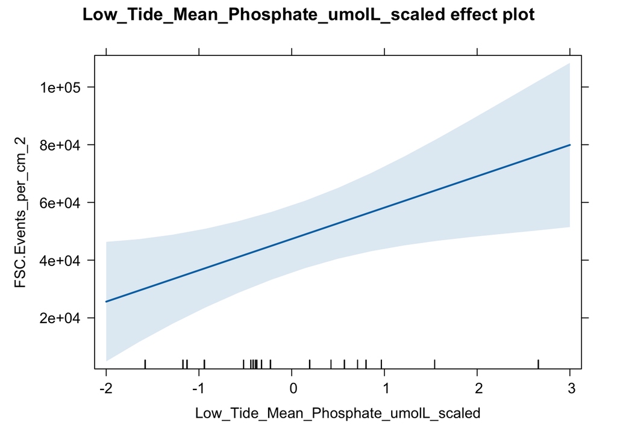